# Western Blot Data: Differential Expression Analysis

2024-02-19 10:17:11

# Load libraries

```r
library(stringr)
library(MASS)
library(car)
library(AICcmodavg)
library(effectsize)
```

# Define functions

```r
findBestModel <- function(varName){
  eval(parse(text=str_c("stepAIC(lm(",varName,"~ grp + batch + Age + Gender, data=dat))")))
}

fitLM <- function(varName){
  eval(parse(text=str_c("lm(",varName,"~ grp + batch + Age + Gender, data=dat)")))
}

fitCandidateModels <- function(varName){
  candidateModels <- list()
  candidateModels[[1]] <- eval(parse(text=str_c("lm(",varName,"~ group, data=dat)")))
  candidateModels[[2]] <- eval(parse(text=str_c("lm(",varName,"~ group + batch, data=dat)")))
  candidateModels[[3]] <- eval(parse(text=str_c("lm(",varName,"~ group + Age, data=dat)")))
  candidateModels[[4]] <- eval(parse(text=str_c("lm(",varName,"~ group + Gender, data=dat)")))
  candidateModels[[5]] <- eval(parse(text=str_c("lm(",varName,"~ group + batch + Age, data=dat)")))
  candidateModels[[6]] <- eval(parse(text=str_c("lm(",varName,"~ group + batch + Gender, data=dat)")))
  candidateModels[[7]] <- eval(parse(text=str_c("lm(",varName,"~ group + Age + Gender, data=dat)")))
  candidateModels[[8]] <- eval(parse(text=str_c("lm(",varName,"~ group + batch + Age + Gender, data=dat)")))
  return(candidateModels)
}

modelNames <- c("group",
"group+batch",
"group+Age",
"group+Gender",
"group+batch+Age",
"group+batch+Gender",
"group+Age+Gender",
"group+batch+Age+Gender")


processVariable <- function(varName, diag=TRUE){
  cat("\n\n## ", varName,"\n")
  cat("\n\n### Performance of candidate models\n")
  candidateModels <- fitCandidateModels(varName)
  resTab <- aictab(cand.set = candidateModels, modnames = modelNames)
  print(knitr::kable(resTab))

  idxBestModel <- as.numeric(row.names(resTab)[1])
  if(diag){
    cat("\n\n### Diagnostics for best model")
    plot(candidateModels[[idxBestModel]])
  }
  (shapiroResid <- shapiro.test(candidateModels[[idxBestModel]]$residuals))
  return(list(indexBest=idxBestModel, bestModel=candidateModels[[idxBestModel]], shapiroResidP=shapiroResid$p.value))
}
```

# Load data

Raw western blot data have been transformed using Box-Cox method (see WB_Box_Cox_transformation.html)

```r
donors <- read.csv("../data/donor_metadata.csv", row.names=1, na.strings="NA")

wb <- read.csv("../data/WB_protein_levels_BoxCox_transformed.csv", row.names=1)
wb <- wb[c(21:40,1:20),]
wbRaw <- read.csv("../data/WB_protein_levels.csv", row.names=1)
wbRaw <- wbRaw[c(21:40,1:20),]

group <- c(rep("P", 20),rep("C", 20))
groupColor <- c(rep("red", 20),rep("blue", 20))
batch <- c(rep("1", 6), rep("2",6), rep("3",6), rep("4",2))
batch <- rep(batch,2)
```

Create data.frame:

```r
dat <- data.frame(cbind(group,
                        batch,
                        donors,
                        wb$ParCort.Cx43,
                        wb$ParCort.GFAP,
                        wb$ParCort.ALdh1L1,
                        wb$ParCort.GDNF,
                        wb$StriBG.Cx43,
                        wb$StriBG.GFAP,
                        wb$StriBG.ALdh1L1,
                        wb$StriBG.GDNF,
                        wb$MidSN.Cx43,
                        wb$MidSN.GFAP,
                        wb$MidSN.ALdh1L1,
                        wb$MidSN.GDNF))

varNames <- names(dat)[21:32] <- c("ParCort.Cx43",
                "ParCort.GFAP",
                "ParCort.ALdh1L1",
                "ParCort.GDNF",
                "StriBG.Cx43",
                "StriBG.GFAP",
                "StriBG.ALdh1L1",
                "StriBG.GDNF",
                "MidSN.Cx43",
                "MidSN.GFAP",
                "MidSN.ALdh1L1",
                "MidSN.GDNF")
```

# Find best model for each variable

```r
bestModels <- lapply(varNames, processVariable, diag=F)
```

## ParCort.Cx43

### Performance of candidate models

|  | Modnames | K | AICc | Delta_AICc | ModelLik | AICcWt | LL | Cum.Wt |
| --- | --- | --- | --- | --- | --- | --- | --- | --- |
| 1 | group | 3 | 92.18308 | 0.000000 | 1.0000000 | 0.3986936 | -42.75821 | 0.3986936 |
| 3 | group+Age | 4 | 93.78564 | 1.602559 | 0.4487543 | 0.1789155 | -42.32139 | 0.5776091 |
| 2 | group+batch | 6 | 94.24604 | 2.062967 | 0.3564777 | 0.1421254 | -39.85030 | 0.7197344 |
| 4 | group+Gender | 4 | 94.65177 | 2.468690 | 0.2910254 | 0.1160299 | -42.75446 | 0.8357644 |
| 5 | group+batch+Age | 7 | 95.91202 | 3.728943 | 0.1549781 | 0.0617888 | -39.20601 | 0.8975532 |
| 7 | group+Age+Gender | 5 | 96.38557 | 4.202488 | 0.1223042 | 0.0487619 | -42.31043 | 0.9463151 |
| 6 | group+batch+Gender | 7 | 96.84157 | 4.658492 | 0.0973691 | 0.0388204 | -39.67078 | 0.9851355 |
| 8 | group+batch+Age+Gender | 8 | 98.76152 | 6.578440 | 0.0372829 | 0.0148645 | -39.05818 | 1.0000000 |

## ParCort.GFAP

### Performance of candidate models

|  | Modnames | K | AICc | Delta_AICc | ModelLik | AICcWt | LL | Cum.Wt |
| --- | --- | --- | --- | --- | --- | --- | --- | --- |
| 3 | group+Age | 4 | 3.092130 | 0.000000 | 1.0000000 | 0.5220599 | 3.025364 | 0.5220599 |
| 1 | group | 3 | 4.736105 | 1.643975 | 0.4395572 | 0.2294752 | 0.965281 | 0.7515351 |
| 7 | group+Age+Gender | 5 | 5.564194 | 2.472064 | 0.2905347 | 0.1516765 | 3.100256 | 0.9032116 |
| 4 | group+Gender | 4 | 7.154751 | 4.062621 | 0.1311635 | 0.0684752 | 0.994053 | 0.9716868 |
| 5 | group+batch+Age | 7 | 10.569739 | 7.477609 | 0.0237825 | 0.0124159 | 3.465131 | 0.9841027 |
| 2 | group+batch | 6 | 10.881989 | 7.789859 | 0.0203448 | 0.0106212 | 1.831733 | 0.9947239 |
| 8 | group+batch+Age+Gender | 8 | 13.571601 | 10.479471 | 0.0053017 | 0.0027678 | 3.536780 | 0.9974917 |
| 6 | group+batch+Gender | 7 | 13.768462 | 10.676331 | 0.0048047 | 0.0025083 | 1.865769 | 1.0000000 |

## ParCort.ALdh1L1

### Performance of candidate models

|  | Modnames | K | AICc | Delta_AICc | ModelLik | AICcWt | LL | Cum.Wt |
| --- | --- | --- | --- | --- | --- | --- | --- | --- |
| 1 | group | 3 | 53.48978 | 0.000000 | 1.0000000 | 0.5130591 | -23.41155 | 0.5130591 |
| 3 | group+Age | 4 | 55.90211 | 2.412337 | 0.2993420 | 0.1535801 | -23.37963 | 0.6666393 |
| 4 | group+Gender | 4 | 55.93029 | 2.440516 | 0.2951540 | 0.1514315 | -23.39372 | 0.8180708 |
| 2 | group+batch | 6 | 56.90897 | 3.419189 | 0.1809391 | 0.0928325 | -21.18176 | 0.9109032 |
| 7 | group+Age+Gender | 5 | 58.48167 | 4.991894 | 0.0824183 | 0.0422855 | -23.35848 | 0.9531887 |
| 6 | group+batch+Gender | 7 | 59.86084 | 6.371060 | 0.0413563 | 0.0212182 | -21.18042 | 0.9744069 |
| 5 | group+batch+Age | 7 | 59.86349 | 6.373716 | 0.0413014 | 0.0211901 | -21.18175 | 0.9955970 |
| 8 | group+batch+Age+Gender | 8 | 63.00600 | 9.516220 | 0.0085818 | 0.0044030 | -21.18042 | 1.0000000 |

## ParCort.GDNF

### Performance of candidate models

|  | Modnames | K | AICc | Delta_AICc | ModelLik | AICcWt | LL | Cum.Wt |
| --- | --- | --- | --- | --- | --- | --- | --- | --- |
| 2 | group+batch | 6 | 191.4029 | 0.000000 | 1.0000000 | 0.2774777 | -88.42875 | 0.2774777 |
| 5 | group+batch+Age | 7 | 192.4583 | 1.055404 | 0.5899592 | 0.1637005 | -87.47917 | 0.4411783 |
| 1 | group | 3 | 192.7887 | 1.385745 | 0.5001374 | 0.1387770 | -93.06101 | 0.5799552 |
| 3 | group+Age | 4 | 193.1308 | 1.727864 | 0.4215014 | 0.1169572 | -91.99398 | 0.6969125 |
| 6 | group+batch+Gender | 7 | 193.3350 | 1.932072 | 0.3805887 | 0.1056049 | -87.91751 | 0.8025174 |
| 4 | group+Gender | 4 | 194.1490 | 2.746036 | 0.2533412 | 0.0702965 | -92.50306 | 0.8728139 |
| 7 | group+Age+Gender | 5 | 194.3486 | 2.945647 | 0.2292772 | 0.0636193 | -91.29194 | 0.9364332 |
| 8 | group+batch+Age+Gender | 8 | 194.3502 | 2.947300 | 0.2290878 | 0.0635668 | -86.85254 | 1.0000000 |

## StriBG.Cx43

### Performance of candidate models

|  | Modnames | K | AICc | Delta_AICc | ModelLik | AICcWt | LL | Cum.Wt |
| --- | --- | --- | --- | --- | --- | --- | --- | --- |
| 2 | group+batch | 6 | 127.9059 | 0.0000000 | 1.0000000 | 0.4796973 | -56.68023 | 0.4796973 |
| 5 | group+batch+Age | 7 | 128.6414 | 0.7355124 | 0.6922860 | 0.3320877 | -55.57071 | 0.8117850 |
| 6 | group+batch+Gender | 7 | 130.8411 | 2.9352115 | 0.2304766 | 0.1105590 | -56.67056 | 0.9223440 |
| 8 | group+batch+Age+Gender | 8 | 131.7834 | 3.8775024 | 0.1438835 | 0.0690205 | -55.56912 | 0.9913645 |
| 1 | group | 3 | 137.0309 | 9.1249777 | 0.0104361 | 0.0050061 | -65.18211 | 0.9963706 |
| 3 | group+Age | 4 | 139.1880 | 11.2820929 | 0.0035492 | 0.0017025 | -65.02257 | 0.9980732 |
| 4 | group+Gender | 4 | 139.4924 | 11.5865349 | 0.0030480 | 0.0014621 | -65.17479 | 0.9995353 |
| 7 | group+Age+Gender | 5 | 141.7849 | 13.8789679 | 0.0009688 | 0.0004647 | -65.01008 | 1.0000000 |

## StriBG.GFAP

### Performance of candidate models

|  | Modnames | K | AICc | Delta_AICc | ModelLik | AICcWt | LL | Cum.Wt |
| --- | --- | --- | --- | --- | --- | --- | --- | --- |
| 1 | group | 3 | 46.60873 | 0.0000000 | 1.0000000 | 0.3614013 | -19.97103 | 0.3614013 |
| 3 | group+Age | 4 | 46.90016 | 0.2914334 | 0.8644026 | 0.3123962 | -18.87865 | 0.6737975 |
| 4 | group+Gender | 4 | 49.08203 | 2.4733033 | 0.2903548 | 0.1049346 | -19.96959 | 0.7787321 |
| 7 | group+Age+Gender | 5 | 49.52034 | 2.9116161 | 0.2332118 | 0.0842831 | -18.87782 | 0.8630152 |
| 5 | group+batch+Age | 7 | 50.31618 | 3.7074529 | 0.1566523 | 0.0566144 | -16.40809 | 0.9196295 |
| 2 | group+batch | 6 | 50.45255 | 3.8438223 | 0.1463270 | 0.0528828 | -17.95355 | 0.9725123 |
| 8 | group+batch+Age+Gender | 8 | 53.10961 | 6.5008849 | 0.0387571 | 0.0140069 | -16.23223 | 0.9865191 |
| 6 | group+batch+Gender | 7 | 53.18616 | 6.5774361 | 0.0373016 | 0.0134809 | -17.84308 | 1.0000000 |

## StriBG.ALdh1L1

### Performance of candidate models

|  | Modnames | K | AICc | Delta_AICc | ModelLik | AICcWt | LL | Cum.Wt |
| --- | --- | --- | --- | --- | --- | --- | --- | --- |
| 1 | group | 3 | 56.94669 | 0.000000 | 1.0000000 | 0.4220811 | -25.14001 | 0.4220811 |
| 4 | group+Gender | 4 | 58.16261 | 1.215928 | 0.5444583 | 0.2298056 | -24.50988 | 0.6518866 |
| 3 | group+Age | 4 | 59.19255 | 2.245859 | 0.3253254 | 0.1373137 | -25.02484 | 0.7892003 |
| 2 | group+batch | 6 | 60.28763 | 3.340939 | 0.1881587 | 0.0794182 | -22.87109 | 0.8686185 |
| 7 | group+Age+Gender | 5 | 60.46912 | 3.522431 | 0.1718359 | 0.0725287 | -24.35221 | 0.9411472 |
| 6 | group+batch+Gender | 7 | 62.27711 | 5.330419 | 0.0695848 | 0.0293704 | -22.38855 | 0.9705176 |
| 5 | group+batch+Age | 7 | 62.87074 | 5.924056 | 0.0517139 | 0.0218275 | -22.68537 | 0.9923451 |
| 8 | group+batch+Age+Gender | 8 | 64.96639 | 8.019704 | 0.0181361 | 0.0076549 | -22.16061 | 1.0000000 |

## StriBG.GDNF

### Performance of candidate models

|  | Modnames | K | AICc | Delta_AICc | ModelLik | AICcWt | LL | Cum.Wt |
| --- | --- | --- | --- | --- | --- | --- | --- | --- |
| 4 | group+Gender | 4 | 132.2825 | 0.000000 | 1.0000000 | 0.3976757 | -61.56981 | 0.3976757 |
| 7 | group+Age+Gender | 5 | 133.4231 | 1.140613 | 0.5653521 | 0.2248268 | -60.82919 | 0.6225025 |
| 1 | group | 3 | 133.5563 | 1.273802 | 0.5289291 | 0.2103423 | -63.44480 | 0.8328448 |
| 3 | group+Age | 4 | 134.9633 | 2.680792 | 0.2617420 | 0.1040884 | -62.91020 | 0.9369332 |
| 2 | group+batch | 6 | 137.9279 | 5.645413 | 0.0594448 | 0.0236398 | -61.69121 | 0.9605730 |
| 6 | group+batch+Gender | 7 | 138.4544 | 6.171963 | 0.0456852 | 0.0181679 | -60.47722 | 0.9787409 |
| 5 | group+batch+Age | 7 | 139.3524 | 7.069918 | 0.0291600 | 0.0115962 | -60.92619 | 0.9903371 |
| 8 | group+batch+Age+Gender | 8 | 139.7172 | 7.434681 | 0.0242985 | 0.0096629 | -59.53600 | 1.0000000 |

## MidSN.Cx43

### Performance of candidate models

|  | Modnames | K | AICc | Delta_AICc | ModelLik | AICcWt | LL | Cum.Wt |
| --- | --- | --- | --- | --- | --- | --- | --- | --- |
| 1 | group | 3 | 81.23815 | 0.000000 | 1.0000000 | 0.4553744 | -37.26613 | 0.4553744 |
| 3 | group+Age | 4 | 82.77213 | 1.533983 | 0.4644080 | 0.2114795 | -36.78000 | 0.6668540 |
| 4 | group+Gender | 4 | 83.72511 | 2.486963 | 0.2883785 | 0.1313202 | -37.25649 | 0.7981742 |
| 2 | group+batch | 6 | 84.53868 | 3.300532 | 0.1919988 | 0.0874314 | -34.91450 | 0.8856055 |
| 7 | group+Age+Gender | 5 | 85.43089 | 4.192742 | 0.1229016 | 0.0559663 | -36.77794 | 0.9415718 |
| 5 | group+batch+Age | 7 | 86.78709 | 5.548947 | 0.0623823 | 0.0284073 | -34.52688 | 0.9699791 |
| 6 | group+batch+Gender | 7 | 87.17642 | 5.938273 | 0.0513476 | 0.0233824 | -34.72154 | 0.9933615 |
| 8 | group+batch+Age+Gender | 8 | 89.69461 | 8.456468 | 0.0145781 | 0.0066385 | -34.36455 | 1.0000000 |

## MidSN.GFAP

### Performance of candidate models

|  | Modnames | K | AICc | Delta_AICc | ModelLik | AICcWt | LL | Cum.Wt |
| --- | --- | --- | --- | --- | --- | --- | --- | --- |
| 1 | group | 3 | 73.43336 | 0.0000000 | 1.0000000 | 0.3849915 | -33.36374 | 0.3849915 |
| 3 | group+Age | 4 | 74.37879 | 0.9454266 | 0.6233088 | 0.2399686 | -32.58333 | 0.6249600 |
| 2 | group+batch | 6 | 75.71808 | 2.2847259 | 0.3190642 | 0.1228370 | -30.50420 | 0.7477970 |
| 4 | group+Gender | 4 | 75.93852 | 2.5051655 | 0.2857658 | 0.1100174 | -33.36320 | 0.8578144 |
| 7 | group+Age+Gender | 5 | 77.02442 | 3.5910660 | 0.1660389 | 0.0639236 | -32.57471 | 0.9217380 |
| 5 | group+batch+Age | 7 | 77.85411 | 4.4207505 | 0.1096595 | 0.0422180 | -30.06039 | 0.9639559 |
| 6 | group+batch+Gender | 7 | 78.71586 | 5.2824969 | 0.0712722 | 0.0274392 | -30.49126 | 0.9913951 |
| 8 | group+batch+Age+Gender | 8 | 81.03515 | 7.6017894 | 0.0223508 | 0.0086049 | -30.03482 | 1.0000000 |

## MidSN.ALdh1L1

### Performance of candidate models

|  | Modnames | K | AICc | Delta_AICc | ModelLik | AICcWt | LL | Cum.Wt |
| --- | --- | --- | --- | --- | --- | --- | --- | --- |
| 1 | group | 3 | 57.13202 | 0.0000000 | 1.0000000 | 0.3615151 | -25.21307 | 0.3615151 |
| 4 | group+Gender | 4 | 58.09773 | 0.9657052 | 0.6170208 | 0.2230623 | -24.44280 | 0.5845775 |
| 3 | group+Age | 4 | 59.59686 | 2.4648377 | 0.2915864 | 0.1054129 | -25.19237 | 0.6899904 |
| 2 | group+batch | 6 | 59.70689 | 2.5748652 | 0.2759784 | 0.0997704 | -22.49861 | 0.7897607 |
| 6 | group+batch+Gender | 7 | 59.81485 | 2.6828277 | 0.2614757 | 0.0945274 | -21.04076 | 0.8842882 |
| 7 | group+Age+Gender | 5 | 60.66729 | 3.5352638 | 0.1707368 | 0.0617239 | -24.39614 | 0.9460121 |
| 5 | group+batch+Age | 7 | 62.27258 | 5.1405574 | 0.0765142 | 0.0276610 | -22.26962 | 0.9736732 |
| 8 | group+batch+Age+Gender | 8 | 62.37145 | 5.2394301 | 0.0728236 | 0.0263268 | -20.70297 | 1.0000000 |

## MidSN.GDNF

### Performance of candidate models

|  | Modnames | K | AICc | Delta_AICc | ModelLik | AICcWt | LL | Cum.Wt |
| --- | --- | --- | --- | --- | --- | --- | --- | --- |
| 1 | group | 3 | 169.3415 | 0.0000000 | 1.0000000 | 0.3730802 | -81.31781 | 0.3730802 |
| 3 | group+Age | 4 | 169.7649 | 0.4233771 | 0.8092167 | 0.3019027 | -80.27638 | 0.6749830 |
| 4 | group+Gender | 4 | 171.3818 | 2.0403173 | 0.3605377 | 0.1345095 | -81.08485 | 0.8094925 |
| 7 | group+Age+Gender | 5 | 171.7580 | 2.4164862 | 0.2987216 | 0.1114471 | -79.94149 | 0.9209396 |
| 2 | group+batch | 6 | 173.7048 | 4.3632630 | 0.1128573 | 0.0421048 | -79.49754 | 0.9630444 |
| 5 | group+batch+Age | 7 | 175.0138 | 5.6723111 | 0.0586507 | 0.0218814 | -78.64024 | 0.9849258 |
| 6 | group+batch+Gender | 7 | 176.5569 | 7.2154045 | 0.0271141 | 0.0101157 | -79.41178 | 0.9950415 |
| 8 | group+batch+Age+Gender | 8 | 177.9829 | 8.6413980 | 0.0132906 | 0.0049585 | -78.50869 | 1.0000000 |

```r
bmDF <- data.frame(cbind(Variable=varNames, Best.Model=rep(NA,length(bestModels)), ShapiroResidP=rep(NA,length(bestModels))))
for (i in 1:length(bestModels)){
  bmDF$Best.Model[i]<- modelNames[bestModels[[i]]$indexBest]
  bmDF$ShapiroResidP[i] <- bestModels[[i]]$shapiroResidP
}

bmDF$ShapiroResidP <- round(as.numeric(bmDF$ShapiroResidP),3)
#bmDF$ShapiroResidP <- ifelse(bmDF$ShapiroResidP==0, "<0.001", bmDF$ShapiroResidP)

names(bmDF) <- c("Variable", "Best Model", "Shapiro-Wilk Test on Model Residuals (p-value)")

cat("\n")
```

```r
print(knitr::kable(bmDF))
```

| Variable | Best Model | Shapiro-Wilk Test on Model Residuals (p-value) |
| --- | --- | --- |
| ParCort.Cx43 | group | 0.164 |
| ParCort.GFAP | group+Age | 0.978 |
| ParCort.ALdh1L1 | group | 0.048 |
| ParCort.GDNF | group+batch | 0.526 |
| StriBG.Cx43 | group+batch | 0.112 |
| StriBG.GFAP | group | 0.265 |
| StriBG.ALdh1L1 | group | 0.049 |
| StriBG.GDNF | group+Gender | 0.287 |
| MidSN.Cx43 | group | 0.553 |
| MidSN.GFAP | group | 0.702 |
| MidSN.ALdh1L1 | group | 0.071 |
| MidSN.GDNF | group | 0.736 |

*N.B. Model residuals should follow a normal distribution. Here we see that the residuals of the models for ParCort.ALdh1L1 and StriBG.ALdh1L1 do not. However, as we’ll see in the next section, we are not claiming that either of these variables differ in expression between Parkinson’s Disease patients and controls. Moreover, non-parametric tests didn’t show differential expression of either variable, so I don’t think we’re failing to detect a real difference between the two groups.*

# ANOVA

```r
anovaRawP <- rep(NA,length(bestModels))
epsilonSquared <- rep(NA, length(bestModels))
meanControl <- meanPD <- sdControl <- sdPD <- rep(NA, length(varNames))

for (i in 1:length(bestModels)){
  anovaTab <- Anova(bestModels[[i]]$bestModel, type="II")
  anovaRawP[i] <- anovaTab$`Pr(>F)`[row.names(anovaTab)=="group"]
  epsilonSquared[i] <- epsilon_squared(anovaTab)[[2]][1]
  rawVar <- eval(parse(text=str_c("wbRaw$",varNames[i])))
  meanControl[i] <- mean(rawVar[group=="C"], na.rm=TRUE)
  sdControl[i] <- sd(rawVar[group=="C"], na.rm=TRUE)
  meanPD[i] <- mean(rawVar[group=="P"], na.rm=TRUE)
  sdPD[i] <- sd(rawVar[group=="P"], na.rm=TRUE)
}
```

[output not shown]

```r
holm <- p.adjust(anovaRawP, method="holm")
bh <- p.adjust(anovaRawP, method="BH")

effectInterpretation <- interpret_epsilon_squared(epsilonSquared)

nControl <- apply(wb[group=="C",],2,function(x){length(x)-sum(is.na(x))})
nPD <- apply(wb[group=="P",],2,function(x){length(x)-sum(is.na(x))})

resTab <- data.frame(cbind(varNames, nControl, nPD,
                           format(round(anovaRawP,4), scientific=FALSE),
                           format(round(holm,4), scientific=FALSE),
                           format(round(bh,4), scientific=FALSE),
                           round(epsilonSquared,4), effectInterpretation,
                           round(meanControl,4), round(sdControl,4),
                           round(meanPD,4), round(sdPD,4)))
names(resTab) <- c("Variable", "Control n", "PD n", "Raw p-value", "Adj. p-value (FWER)", "Adj. p-value (FDR)", "Effect size (epsilon2)", "Effect size (qualitative)",
                   "Mean Control", "SD Control", "Mean PD", "SD PD")
knitr::kable(resTab)
```

|  | Variable | Control n | PD n | Raw p-value | Adj. p-value (FWER) | Adj. p-value (FDR) | Effect size (epsilon2) | Effect size (qualitative) | Mean Control | SD Control | Mean PD | SD PD |
| --- | --- | --- | --- | --- | --- | --- | --- | --- | --- | --- | --- | --- |
| ParCort.Cx43 | ParCort.Cx43 | 20 | 20 | 0.0040 | 0.0396 | 0.0159 | 0.1774 | large | 0.6928 | 0.4624 | 0.3125 | 0.1761 |
| ParCort.GFAP | ParCort.GFAP | 20 | 20 | 0.0009 | 0.0094 | 0.0051 | 0.2426 | large | 0.7487 | 0.2019 | 0.9549 | 0.2282 |
| ParCort.ALdh1L1 | ParCort.ALdh1L1 | 20 | 20 | 0.0355 | 0.2128 | 0.0608 | 0.0878 | medium | 1.3424 | 0.5212 | 1.0663 | 0.368 |
| ParCort.GDNF | ParCort.GDNF | 20 | 20 | 0.0138 | 0.0965 | 0.0276 | 0.1372 | medium | 25.0737 | 23.7955 | 43.7279 | 30.6254 |
| StriBG.Cx43 | StriBG.Cx43 | 20 | 20 | 0.0098 | 0.0794 | 0.0236 | 0.1521 | large | 0.5667 | 0.6175 | 0.2192 | 0.1917 |
| StriBG.GFAP | StriBG.GFAP | 20 | 20 | 0.0003 | 0.0038 | 0.0038 | 0.2737 | large | 0.9435 | 0.465 | 1.4572 | 0.3544 |
| StriBG.ALdh1L1 | StriBG.ALdh1L1 | 20 | 20 | 0.3344 | 1.0000 | 0.3956 | 0 | very small | 0.9688 | 0.5071 | 0.8201 | 0.3832 |
| StriBG.GDNF | StriBG.GDNF | 20 | 20 | 0.3626 | 1.0000 | 0.3956 | 0 | very small | 26.0579 | 36.1316 | 33.2197 | 36.7978 |
| MidSN.Cx43 | MidSN.Cx43 | 18 | 20 | 0.1514 | 0.6057 | 0.2019 | 0.0301 | small | 0.3212 | 0.2329 | 0.2174 | 0.2274 |
| MidSN.GFAP | MidSN.GFAP | 18 | 20 | 0.0088 | 0.0794 | 0.0236 | 0.1527 | large | 0.9908 | 0.6832 | 1.529 | 0.5102 |
| MidSN.ALdh1L1 | MidSN.ALdh1L1 | 18 | 20 | 0.0574 | 0.2869 | 0.0861 | 0.0716 | medium | 1.0703 | 0.5451 | 0.7561 | 0.3449 |
| MidSN.GDNF | MidSN.GDNF | 18 | 20 | 0.5662 | 1.0000 | 0.5662 | 0 | very small | 17.745 | 23.1439 | 11.0134 | 11.1701 |

*Notes*

- p-values are for the difference between the Parkinson’s Disease patients and controls.
- FWER: Family-wise error rate
- FDR: False discovery rate
- Effect size ($\epsilon^2$) is the proportion of the variation in the protein expression variable explained by group membership (control *vs* PD).
- Means and SDs are for raw, rather than Box-Cox transformed data. However, linear modelling and ANOVA used Box-Cox transformed data.

*Field’s (2013) qualitative interpretation of effect size*

## Boxplots

### ParCort.Cx43

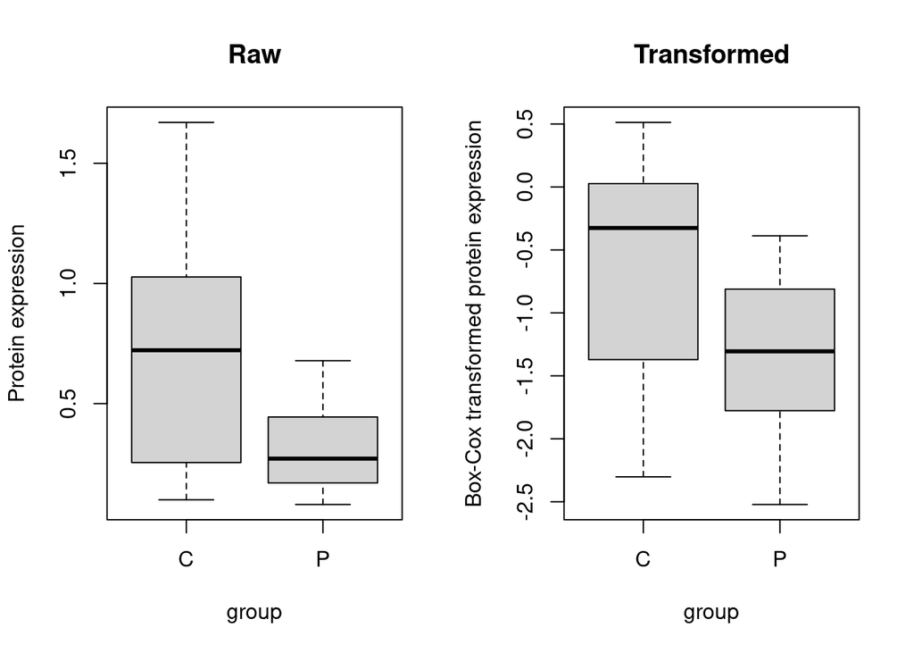

```r
par(mfrow=c(1,2))
boxplot(wbRaw$ParCort.Cx43~group, main="Raw", ylab="Protein expression")
boxplot(wb$ParCort.Cx43~group, main="Transformed", ylab="Box-Cox transformed protein expression")
```

### ParCort.GFAP

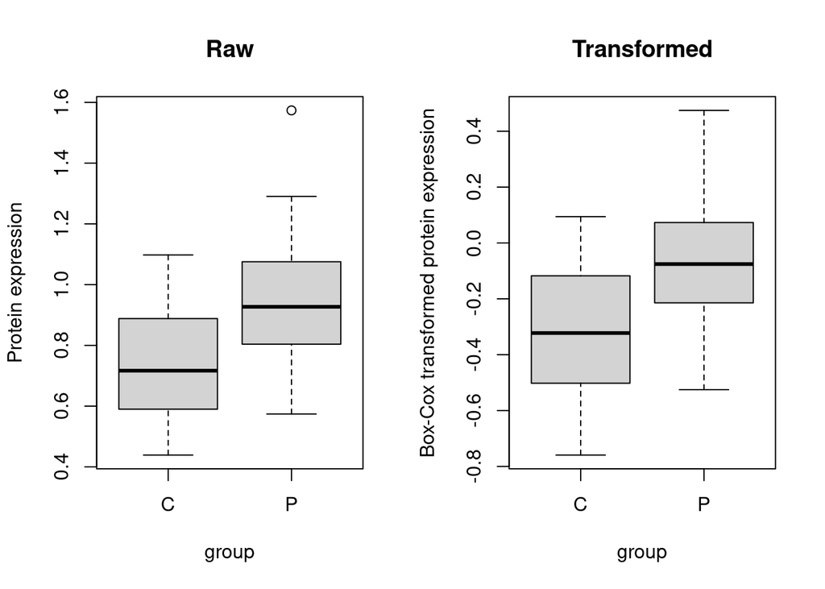

```r
par(mfrow=c(1,2))
boxplot(wbRaw$ParCort.GFAP~group, main="Raw", ylab="Protein expression")
boxplot(wb$ParCort.GFAP~group, main="Transformed", ylab="Box-Cox transformed protein expression")
```

### ParCort.ALdh1L1

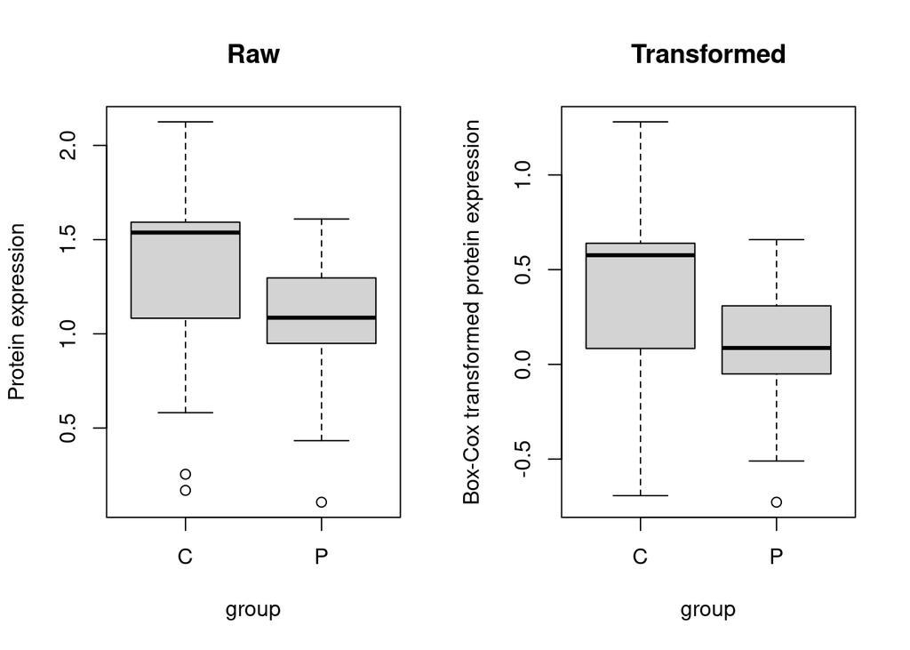

```r
par(mfrow=c(1,2))
boxplot(wbRaw$ParCort.ALdh1L1~group, main="Raw", ylab="Protein expression")
boxplot(wb$ParCort.ALdh1L1~group, main="Transformed", ylab="Box-Cox transformed protein expression")
```

### ParCort.GDNF

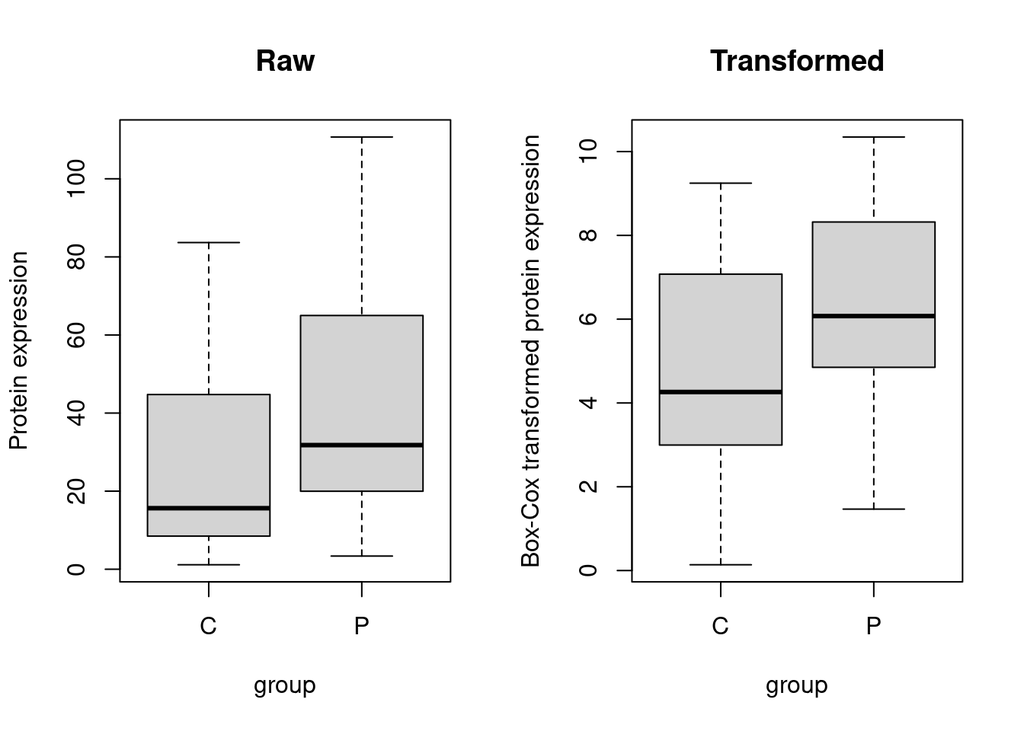

```r
par(mfrow=c(1,2))
boxplot(wbRaw$ParCort.GDNF~group, main="Raw", ylab="Protein expression")
boxplot(wb$ParCort.GDNF~group, main="Transformed", ylab="Box-Cox transformed protein expression")
```

### StriBG.Cx43

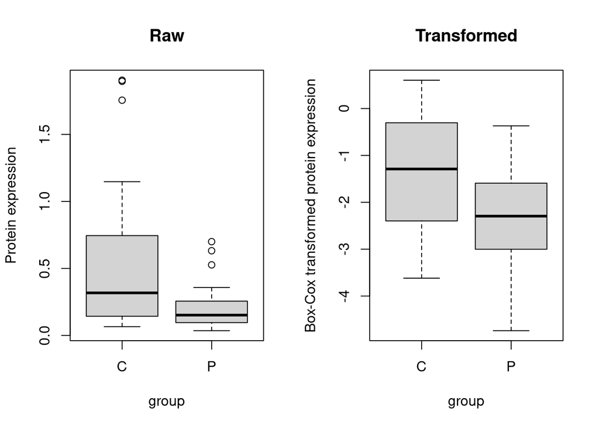

```r
par(mfrow=c(1,2))
boxplot(wbRaw$StriBG.Cx43~group, main="Raw", ylab="Protein expression")
boxplot(wb$StriBG.Cx43~group, main="Transformed", ylab="Box-Cox transformed protein expression")
```

### StriBG.GFAP

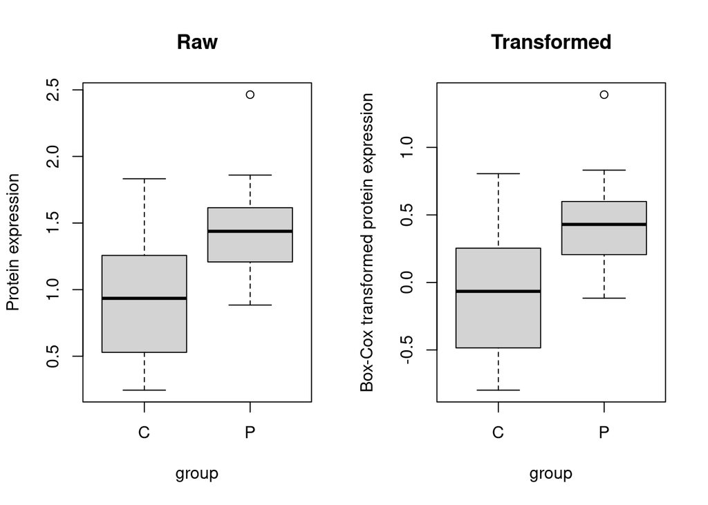

```r
par(mfrow=c(1,2))
boxplot(wbRaw$StriBG.GFAP~group, main="Raw", ylab="Protein expression")
boxplot(wb$StriBG.GFAP~group, main="Transformed", ylab="Box-Cox transformed protein expression")
```

### StriBG.ALdh1L1

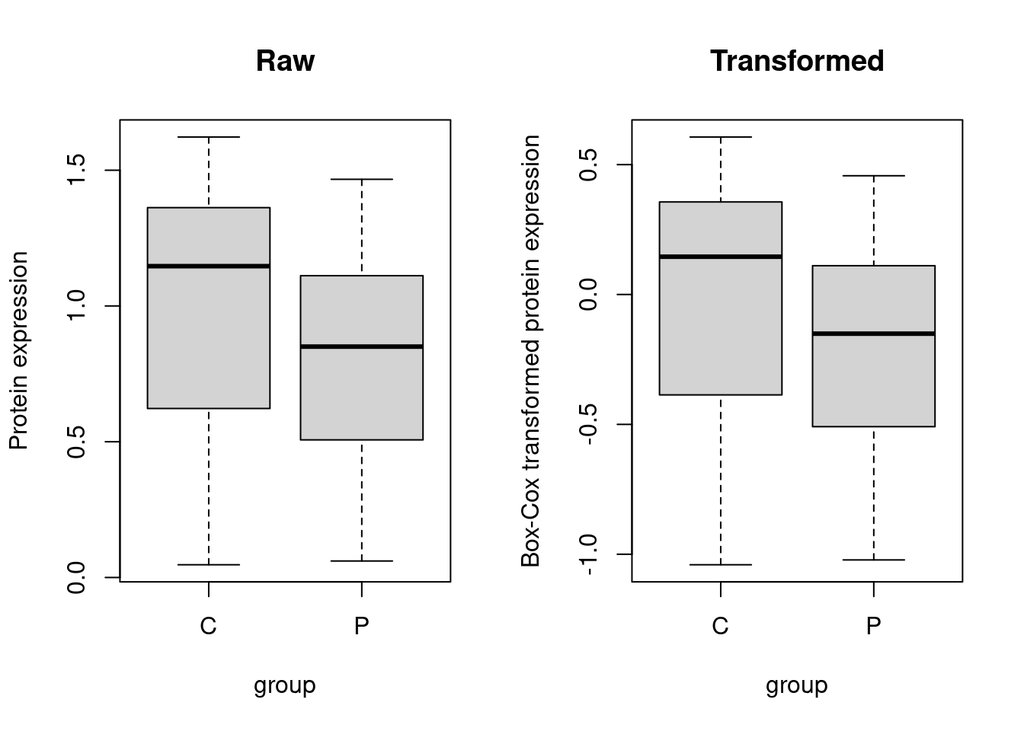

```r
par(mfrow=c(1,2))
boxplot(wbRaw$StriBG.ALdh1L1~group, main="Raw", ylab="Protein expression")
boxplot(wb$StriBG.ALdh1L1~group, main="Transformed", ylab="Box-Cox transformed protein expression")
```

### StriBG.GDNF

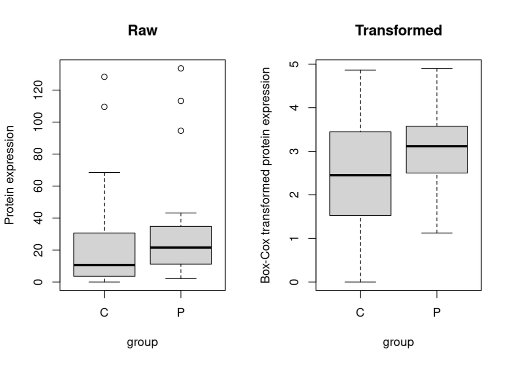

```r
par(mfrow=c(1,2))
boxplot(wbRaw$StriBG.GDNF~group, main="Raw", ylab="Protein expression")
boxplot(wb$StriBG.GDNF~group, main="Transformed", ylab="Box-Cox transformed protein expression")
```

### MidSN.Cx43

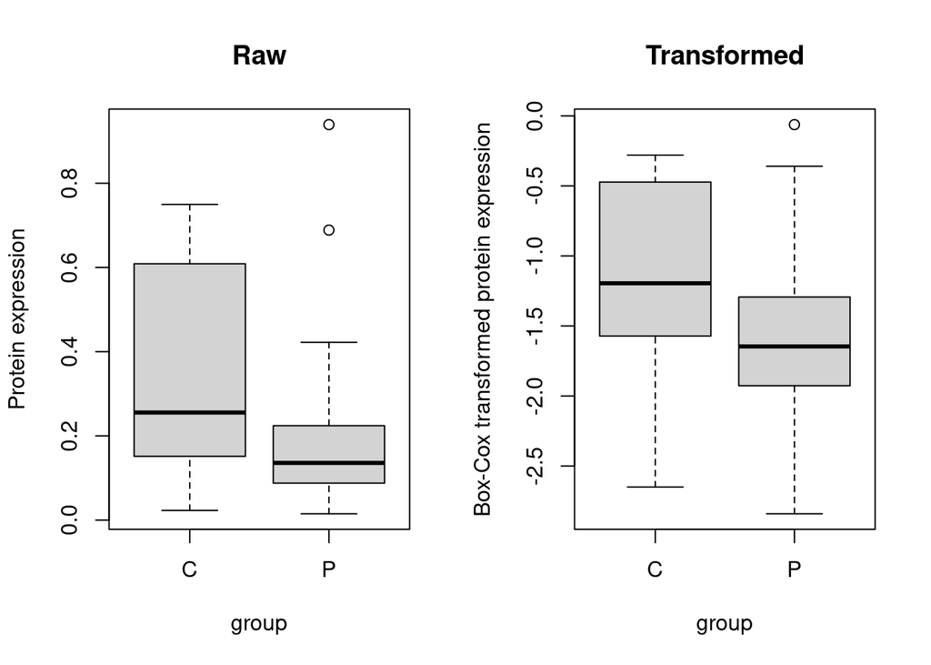

```r
par(mfrow=c(1,2))
boxplot(wbRaw$MidSN.Cx43~group, main="Raw", ylab="Protein expression")
boxplot(wb$MidSN.Cx43~group, main="Transformed", ylab="Box-Cox transformed protein expression")
```

### MidSN.GFAP

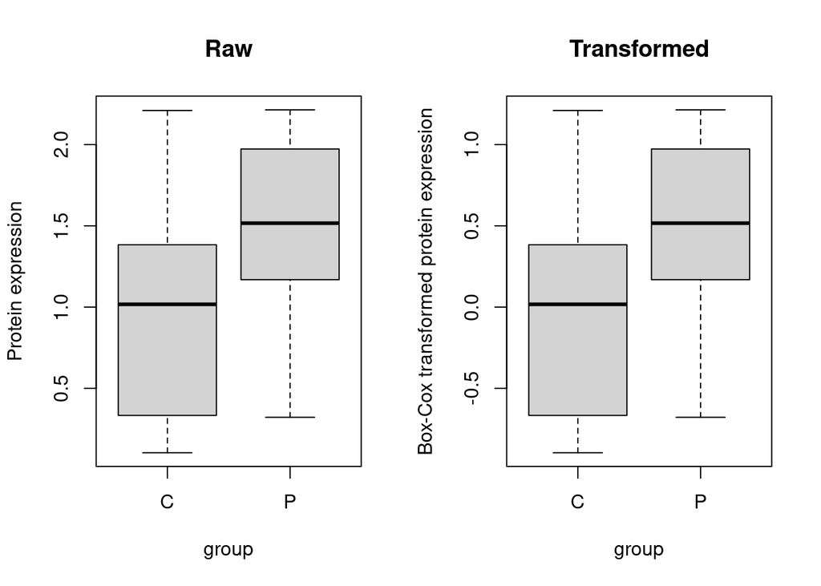

```r
par(mfrow=c(1,2))
boxplot(wbRaw$MidSN.GFAP~group, main="Raw", ylab="Protein expression")
boxplot(wb$MidSN.GFAP~group, main="Transformed", ylab="Box-Cox transformed protein expression")
```

### MidSN.ALdh1L1

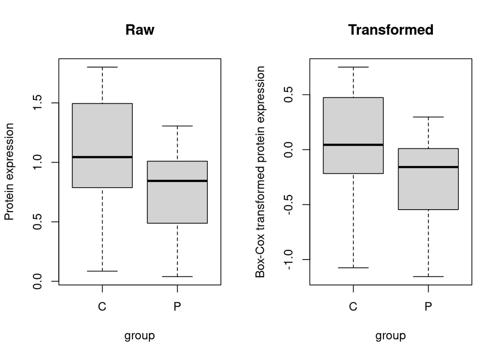

```r
par(mfrow=c(1,2))
boxplot(wbRaw$MidSN.ALdh1L1~group, main="Raw", ylab="Protein expression")
boxplot(wb$MidSN.ALdh1L1~group, main="Transformed", ylab="Box-Cox transformed protein expression")
```

### MidSN.GDNF

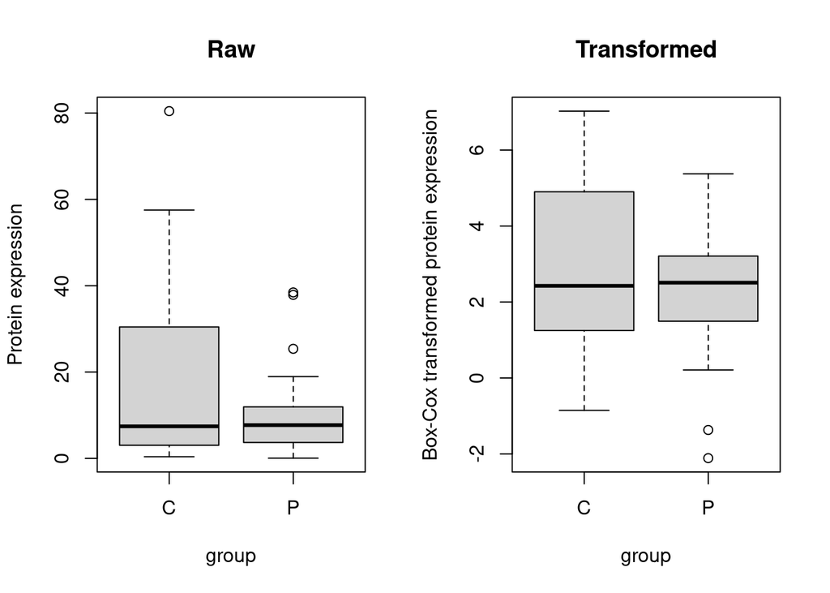

```r
par(mfrow=c(1,2))
boxplot(wbRaw$MidSN.GDNF~group, main="Raw", ylab="Protein expression")
boxplot(wb$MidSN.GDNF~group, main="Transformed", ylab="Box-Cox transformed protein expression")
```

# Importance of the other variables in the best linear models

## Models with additional variables

- ParCort.GFAP group+Age
- ParCort.GDNF group+batch
- StriBG.Cx43 group+batch
- StriBG.GDNF group+Gender

## ParCort.GFAP group+Age

*Model 2 in list of best models.*

Repeat ANOVA:

```r
anovaTable <- Anova(bestModels[[2]]$bestModel, type="II")
```

**Raw p-value for age:**

```r
anovaTable$`Pr(>F)`[row.names(anovaTable)=="Age"]
```

```
## [1] 0.05247861
```

**Effect size $\epsilon^2$ of age:**

```r
es <- epsilon_squared(anovaTable)
(es <- es$Epsilon2_partial[es$Parameter=="Age"])
```

```
## [1] 0.07349504
```

**Qualitative interpretation of effect size of age:**

```r
interpret_epsilon_squared(es)
```

```
## [1] "medium"
## (Rules: field2013)
```

**Scatterplot Age**

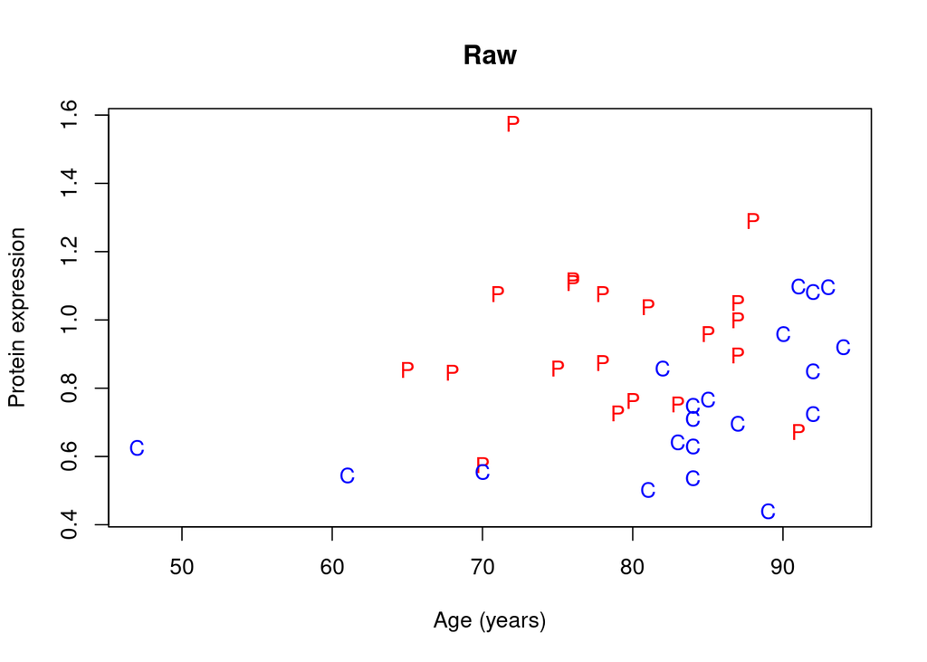

```r
plot(dat$Age, wbRaw$ParCort.GFAP, pch=group, col=groupColor, main="Raw", xlab="Age (years)", ylab="Protein expression")
```

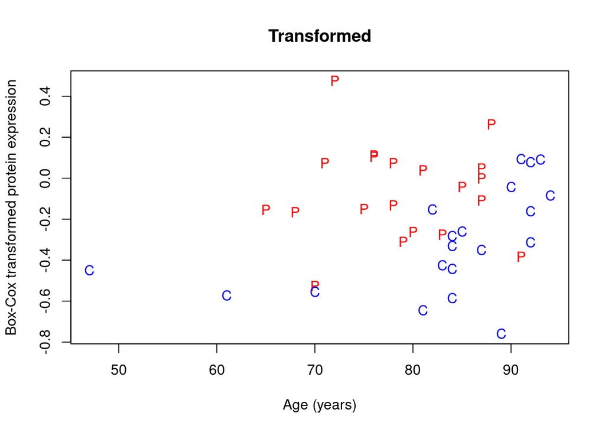

```r
plot(dat$Age, wb$ParCort.GFAP, pch=group, col=groupColor, main="Transformed", xlab="Age (years)", ylab="Box-Cox transformed protein expression")
```

## ParCort.GDNF group+batch

*Model 4 in list of best models.*

Repeat ANOVA:

```r
anovaTable <- Anova(bestModels[[4]]$bestModel, type="II")
```

**Raw p-value for batch:**

```r
anovaTable$`Pr(>F)`[row.names(anovaTable)=="batch"]
```

```
## [1] 0.04170195
```

**Effect size $\epsilon^2$ of batch:**

```r
es <- epsilon_squared(anovaTable)
(es <- es$Epsilon2_partial[es$Parameter=="batch"])
```

```
## [1] 0.1387541
```

**Qualitative interpretation of effect size of batch:**

```r
interpret_epsilon_squared(es)
```

```
## [1] "medium"
## (Rules: field2013)
```

**Boxplot batch**

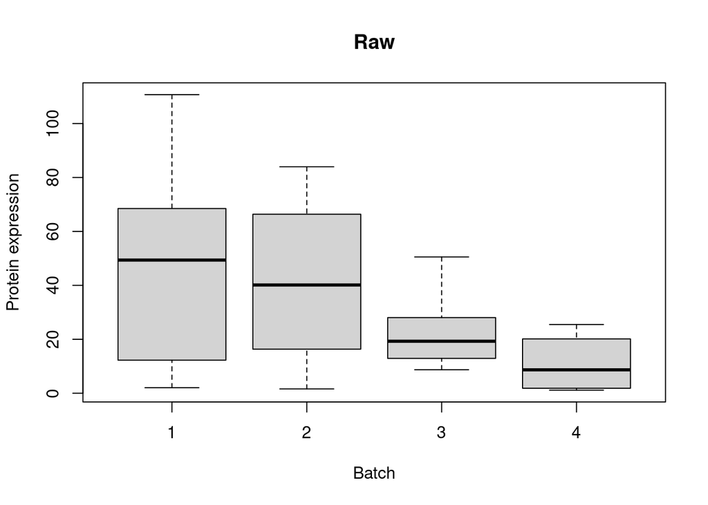

```r
boxplot(wbRaw$ParCort.GDNF~batch, main="Raw", xlab="Batch", ylab="Protein expression")
```

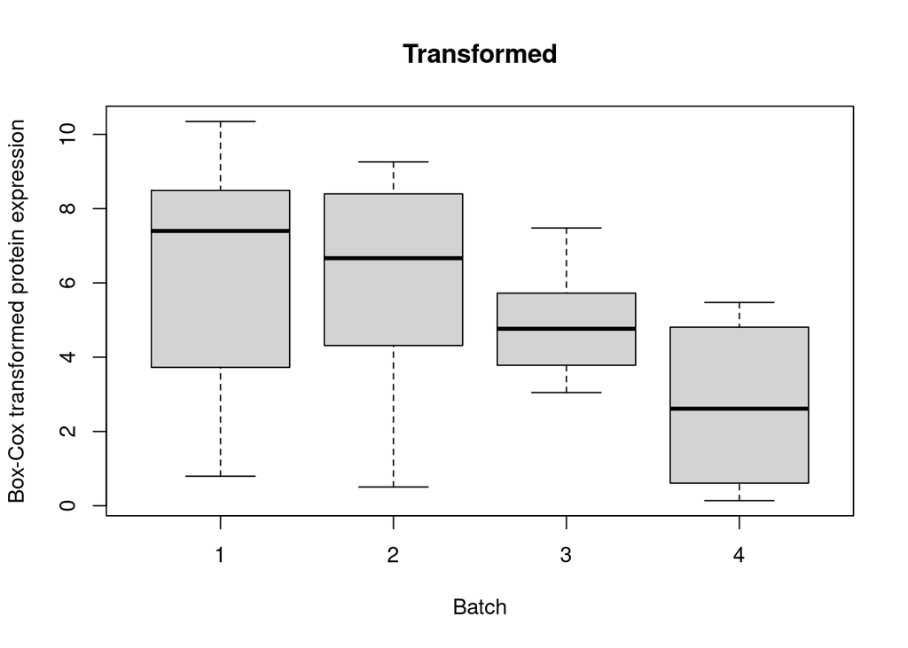

```r
boxplot(wb$ParCort.GDNF~batch, main="Transformed", xlab="Batch", ylab="Box-Cox transformed protein expression")
```

## StriBG.Cx43 group+batch

*Model 5 in list of best models.*

Repeat ANOVA:

```r
anovaTable <- Anova(bestModels[[5]]$bestModel, type="II")
```

**Raw p-value for batch:**

```r
anovaTable$`Pr(>F)`[row.names(anovaTable)=="batch"]
```

```
## [1] 0.001748854
```

**Effect size $\epsilon^2$ of batch:**

```r
es <- epsilon_squared(anovaTable)
(es <- es$Epsilon2_partial[es$Parameter=="batch"])
```

```
## [1] 0.2902596
```

**Qualitative interpretation of effect size of batch:**

```r
interpret_epsilon_squared(es)
```

```
## [1] "large"
## (Rules: field2013)
```

**Boxplot batch**

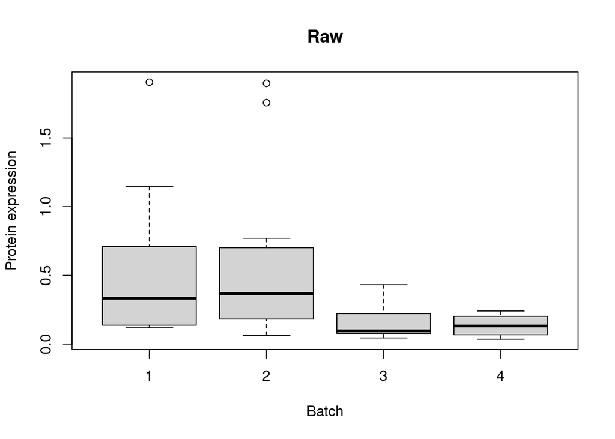

```r
boxplot(wbRaw$StriBG.Cx43~batch, main="Raw", xlab="Batch", ylab="Protein expression")
```

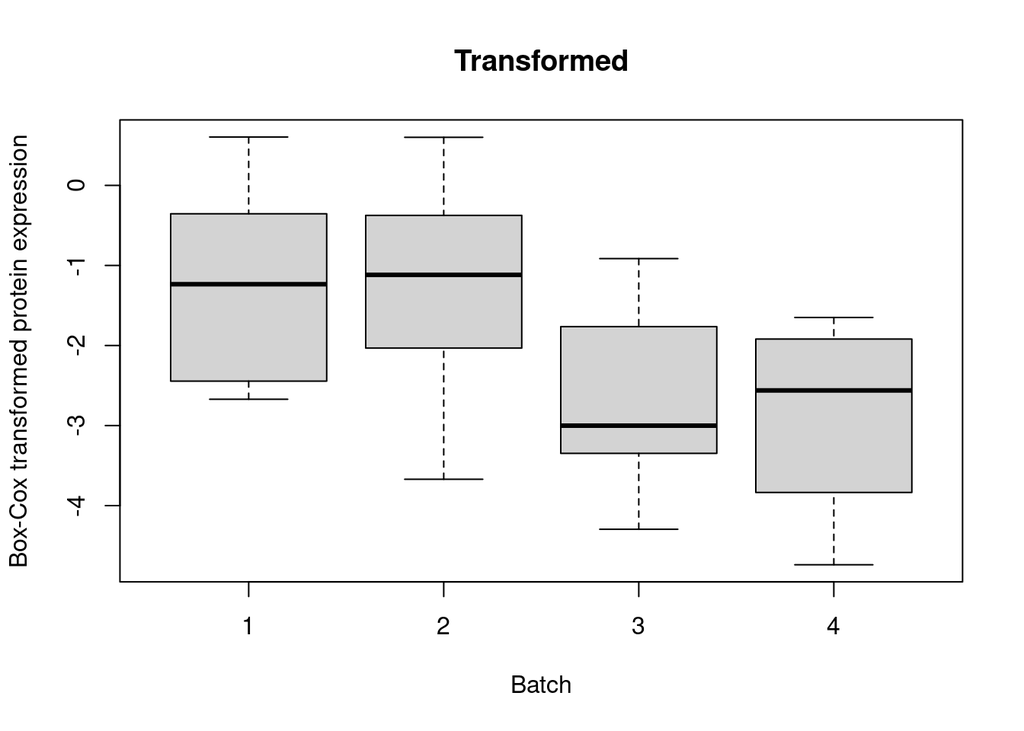

```r
boxplot(wb$StriBG.Cx43~batch, main="Transformed", xlab="Batch", ylab="Box-Cox transformed protein expression")
```